# Salary information for High-Skilled Immigrant Employees on work visas

Author - Anupama Rajaram

Date - January 4, 2017

## Section 1 - Overview:

In this document we will explore Salary information for High-Skilled Immigrant Employees on work visas, using data analysis in R. Some of the questions we will analyze include:

1. Highest Paying Employers, by State.
2. Salary range by job title.
3. Number of visas by Year.

## Section 2 - Data Preparation:

We start by loading the salary dataset given in **salary_data.csv** file and preparing the workspace.

Let’s take a peek at the data.

```r
saldata[1:10, "EMPLOYER_NAME"]
```

```
##  [1] "ADVANCED TECHNOLOGY GROUP USA, INC."
##  [2] "SAN FRANCISCO STATE UNIVERSITY"
##  [3] "CAROUSEL SCHOOL"
##  [4] "HARLINGEN CONSOLIDATED INDEPENDENT SCHOOL DISTRICT"
##  [5] "SIGNAL SCIENCES CORPORATION"
##  [6] "CAPGEMINI U.S. LLC"
##  [7] "PURE STORAGE, INC."
##  [8] "POLMAK, INC."
##  [9] "GOOGLE INC."
## [10] "STLPORT CONSULTING, INC."
```

Next we look at the type of visas and the salary ranges in our dataset.

```r
table(saldata$VISA_CLASS)
```

```
##
##  E-3 Australian       greencard            H-1B     H-1B1 Chile
##            1393           11093          154497             147
## H-1B1 Singapore
##             148
```

```r
summary(saldata$PREVAILING_WAGE_SUBMITTED)
```

```
##    Min. 1st Qu.  Median    Mean 3rd Qu.    Max.
##       5   54500   69700   71200   89900 6220000
```

Number of records by job-types.

```r
table(saldata$JOB_TITLE_SUBGROUP)
```

```
##
##   assistant professor              attorney      business analyst
##                 18866                  1488                 27811
##          data analyst        data scientist management consultant
##                  3840                  1227                   770
##     software engineer               teacher
##                 99364                 13912
```

Next, we will remove columns with more than 70% missing values and create some derived variables. (Code not shown)

We will also create a new Date variable in a standard format.

```r
saldata$case_date = as.Date(saldata$CASE_RECEIVED_DATE, "%m/%d/%Y")
saldata$caseyr = as.numeric(format(saldata$case_date, "%Y"))
```

## Section 3 - Graphical Exploration

2. Visualize number of visas by year and job title.

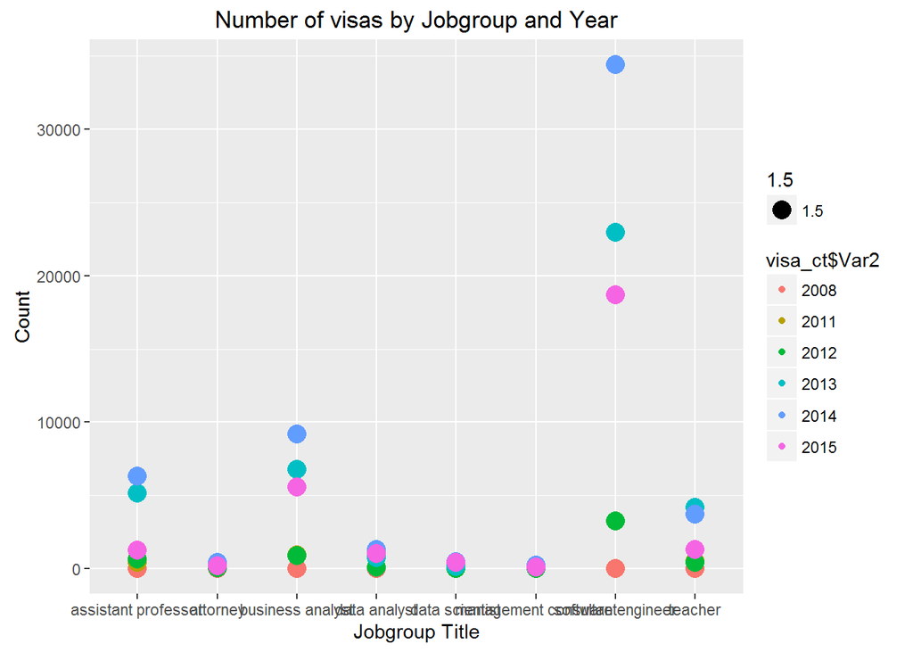

## Section 4 - Data analysis

1. let us aggregate information on the employers with highest number of applications, by State.  
   We see California leads our list.

```r
setctstate = sqldf("select count(*) as 'count',
              EMPLOYER_NAME as 'employer',
              WORK_STATE2 as 'state',
              avg(PAID_WAGE_PER_YEAR) as 'salary'
              from activesal
              group by EMPLOYER_NAME, WORK_STATE2")
#top_setctstate = setctstate[with(setctstate, order(state, -count, -salary)),]
top_setctstate = setctstate[with(setctstate, order( -count)),]
head(top_setctstate)
```

```
##       count                    employer      state salary
## 11321  4195                 GOOGLE INC. california 126006
## 17765  1112       MICROSOFT CORPORATION washington 121732
## 22106   882 QUALCOMM TECHNOLOGIES, INC. california  94285
## 9691    806              FACEBOOK, INC. california 129203
## 13934   732           INTEL CORPORATION california 101627
## 5226    700          CERNER CORPORATION   missouri  69044
```

2)Let us see which states offer the highest salary.

[output not shown]

3) Analyze how software engineers fared! A topic (obviously) close to my heart! We create a dataframe called setstatesal for this analysis.

```r
setstatesal = sqldf("select caseyr as 'year',
                    count(*) as 'count',
                    JOB_TITLE_SUBGROUP as 'title',
                    WORK_STATE2 as 'state',
                    max(PAID_WAGE_PER_YEAR) as 'maxsal',
                    avg(PAID_WAGE_PER_YEAR) as 'avgsal',
                    min(PAID_WAGE_PER_YEAR) as 'minsal'
                    from activesal
                    group by caseyr, JOB_TITLE_SUBGROUP, WORK_STATE2 ")
```

## Section 5 - Data Visualization

1. Visualize states with highest avg salary for software engineers, using ggplot.

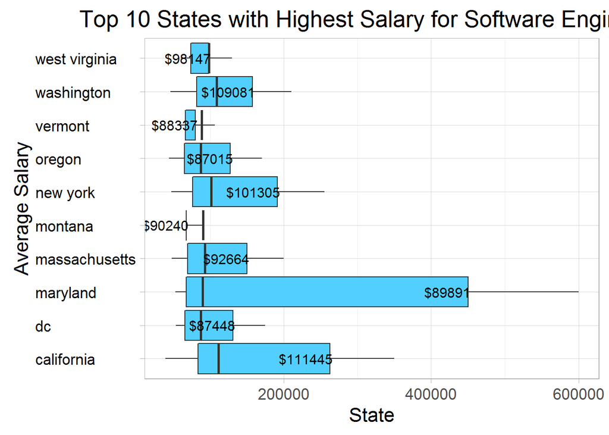

2) Salary by year and avg_salary.  
From graph below, we conclude that Attorneys make the highest salaries, which is not very surprising!  
Also, 2012 was the best year (salary-wise) for foreign software engineers.

[interactive chart not shown]

3) Interactive Map using Leaflet. We create an interactive map to show Top employers in every state.  
Click on the blue marker to see info. The **numbered circles** are clickable links that zoom into the map for a better view.

[interactive chart not shown]

That concludes our analysis for now. Did you like this tutorial? If so, please don’t forget to share!